# AEEM 3062

# HOMEWORK # 9

# 2022-2023 SPRING

### Name: Slade Brooks

### M#: 13801712

### DUE: 11.59 PM on 4/5/2023

## Problem 1

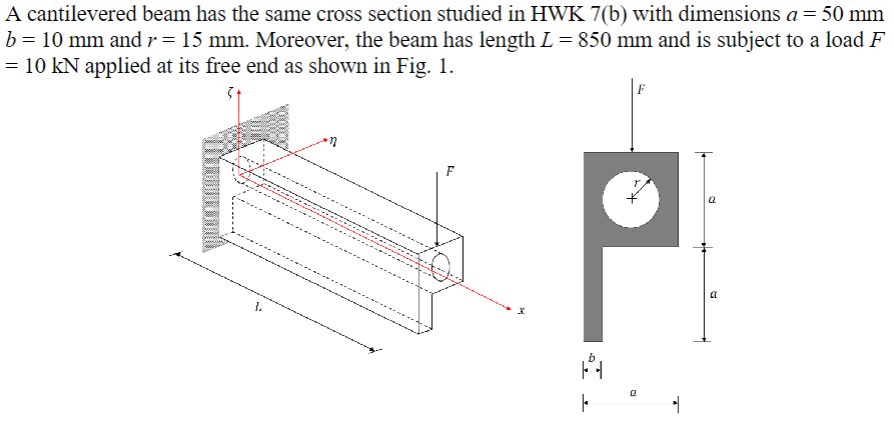

### Part A

First we can find $\alpha$ from the eigenvector $n_2$, where $\theta$ is its angle from the negative horizontal axis.

$$ \alpha = 360 - \theta = 360 - \tan^{-1}(0.3447/0.9387) \\ \alpha = 339.84^\circ $$

Then we can find $\beta$.

$$ \tan{\beta} = \frac{I_y}{I_z}\tan(\alpha) $$

We found $I_y$ and $I_z$ in HW7.

$$ \beta = \tan^{-1}(\frac{1706271}{498047}\tan(339.84)) $$

$$ \beta = -51.51^\circ $$

Therefore the neutral axis is as shown with $\beta = 51.51^\circ$:

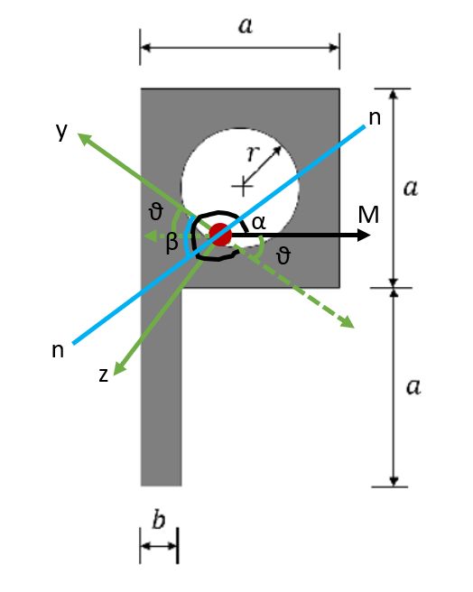

### Part B

First we will transform the coordinates of points A and B shown in the sketch below from $\eta, \zeta$ to $y, z$. This was done with fun geometry to give:

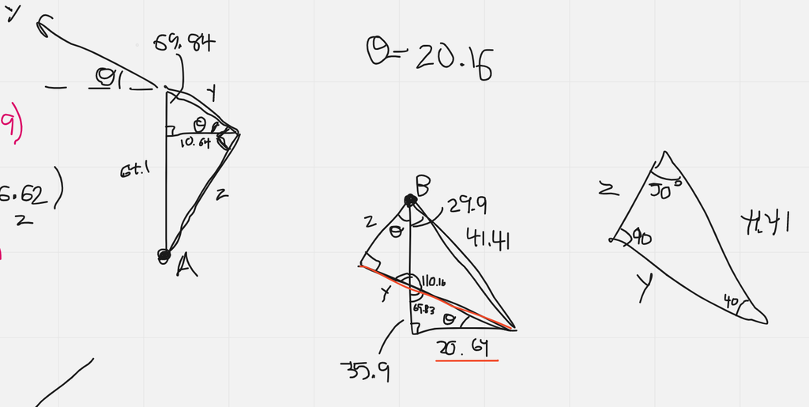

$$ A = (-12.1, 63.84) \\ B = (31.72, -26.62) $$

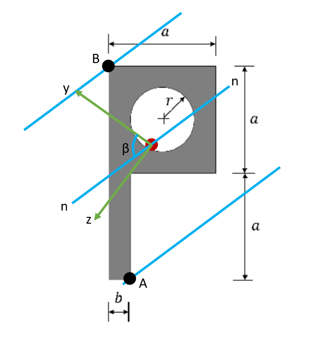

Then we can compute the stress at these points with the equation: $$ \sigma_x = -\frac{M\cos{\alpha}}{I_y}z - \frac{M\sin{\alpha}}{I_z}y $$

M can be found by multiplying the force by the length of the bar since the largest moment will be at the wall: $$ M = (-10\text{kN})(850\text{mm}) = -8500 \text{kNmm} $$

Then: $$ \sigma_{xA} = -\frac{-8500\cos{(339.84-180)}}{1706271}(63.84) - \frac{-8500\sin{(339.84-180)}}{498047}(-12.1) $$

$$ \sigma_{xA} = -0.3697 \text{kN/mm$^2$} = \fbox{$-369.7\text{MPa}$} \ \text{(compression)} $$

$$ \sigma_{xB} = -\frac{-8500\cos{(339.84-180)}}{1706271}(-26.62) - \frac{-8500\sin{(339.84-180)}}{498047}(31.72) $$

$$ \sigma_{xB} = 0.3111\text{kN/mm$^2$} = \fbox{$311.1\text{MPa}$} \ \text{(tension)} $$

Therefore the maximum compressive stress is 369.7 MPa at A and the maximum tensile stress is 311.1 MPa at B.

### Part C

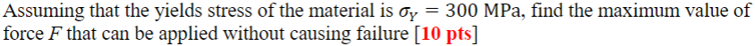

We can check the points A and B to see at what value of F the $\sigma_x$ becomes 300 MPa by rearranging the equation: $$ \sigma_x = -\frac{FL\cos{\alpha}}{I_y}z - \frac{FL\sin{\alpha}}{I_z}y $$

$$ F = \frac{\sigma_x}{L*(-\frac{\cos{\alpha}}{I_y}z - \frac{\sin{\alpha}}{I_z}y)} $$

$$ F_B= \frac{0.3}{850*(-\frac{\cos{(339.84-180)}}{1706271}(-26.62)-\frac{\sin{(339.84-180)}}{498047}(31.72))} $$

### Part D

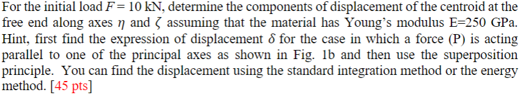

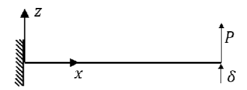

First set up differential equations:

$$ \frac{\partial V}{\partial x} = 0,\\ V = C_1 $$

$$ \frac{\partial M}{\partial x} = V = C_1,\\ M = C_1x + C_2L $$

$$ \frac{\partial \varphi}{\partial x} = \frac{M}{EI} = \frac{1}{EI}(C_1x + C_2L), \\ \varphi = \frac{1}{EI}(\frac{1}{2}C_1x^2 + C_2Lx + C_3L^2) $$

$$ \frac{\partial w}{\partial x} = \varphi = \frac{1}{EI}(\frac{1}{2}C_1x^2 + C_2Lx + C_3L^2), \\ w = \frac{1}{EI}(\frac{C_1}{6}x^3 + \frac{C_2L}{2}x^2 + C_3L^2x + C_4L^3) $$

Now define the boundary conditions:

$$ \varphi(0) = 0 \\ w(0) = 0 \\ V(L) = P \\ M(L) = 0 $$

Then plugging in and solving:

$$ \varphi(0) = 0 = \frac{C_3L^2}{EI}, \\ C_3 = 0 $$

$$ w(0) = 0 = \frac{C_4L^3}{EI}, \\ C_4 = 0 $$

$$ V(L) = P = C_1, \\ C_1 = P $$

$$ M(L) = 0 = L(C_1+C_2),\ C_1 + C_2 = 0,\\ C_2 = -P $$

Plug in the constants and solve for w:

$$ w(x) = \frac{1}{EI}(\frac{P}{6}x^3 - \frac{PL}{2}x^2) $$

$$ w = \frac{-PL^3}{3EI} $$

(at the free end)

Now we will find the displacement in the z direction by finding the component of F in the z direction (P):

$$ P = F\cos{\theta} $$

(where $\theta$ is the angle between n2 and the negative $\eta$ axis)

$$ w = \frac{-F\cos{\theta}L^3}{3EI_z} = -\frac{-10\cos{20.16}(850)^3}{3*250*498047} $$

$$ w_z = 15.434 \text{mm} $$

Then we can find displacement in the y direction by doing the same in the y direction:

$$ P = -F\sin{\theta} $$

$$ w = -\frac{-F\sin{\theta}L^3}{3EI_z} = \frac{10\sin{20.16}(850)^3}{3*250*1706271} $$

$$ w_y = -1.654 \text{mm} $$

Now we can superposition $w_z$ and $w_y$:

$$ w=(-1.654, 15.434) $$

And convert to terms of $\eta$ and $\zeta$ using gross trig ugh:

$$ \fbox{$ w = (-3.765, -15.054) \text{mm}$} $$

$$ (\eta, \zeta) $$

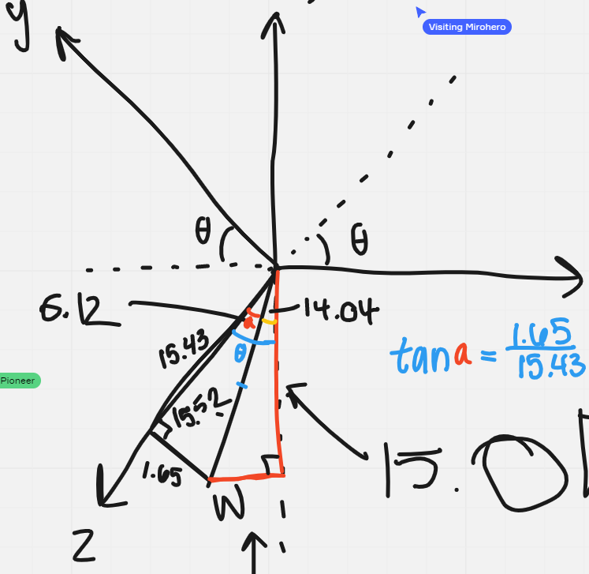